# IODS course project

Let’s see the corresponding summaries first:

```r
alc %>% group_by(sex, high_use) %>% summarise(count = n(), mean_medu = mean(Medu))
```

[output not shown]

```
## # A tibble: 4 × 4
## # Groups:   sex [2]
##   sex   high_use count mean_medu
##   <chr> <lgl>    <int>     <dbl>
## 1 F     FALSE      154      2.69
## 2 F     TRUE        41      2.76
## 3 M     FALSE      105      2.96
## 4 M     TRUE        70      2.81
```

```r
alc %>% group_by(sex, high_use, famsup) %>% summarise(count = n())
```

```
## # A tibble: 8 × 4
## # Groups:   sex, high_use [4]
##   sex   high_use famsup count
##   <chr> <lgl>    <chr>  <int>
## 1 F     FALSE    no        47
## 2 F     FALSE    yes      107
## 3 F     TRUE     no        11
## 4 F     TRUE     yes       30
## 5 M     FALSE    no        47
## 6 M     FALSE    yes       58
## 7 M     TRUE     no        34
## 8 M     TRUE     yes       36
```

From these numbers it seems that there are no big differences between the students whose alcohol consumption is high and those whose alcohol consumption is low. But lest see the box plot for mother’s educational level. Because the Family support is a binary variable, drawing a box plot would not make it very informative. So we do not draw that.

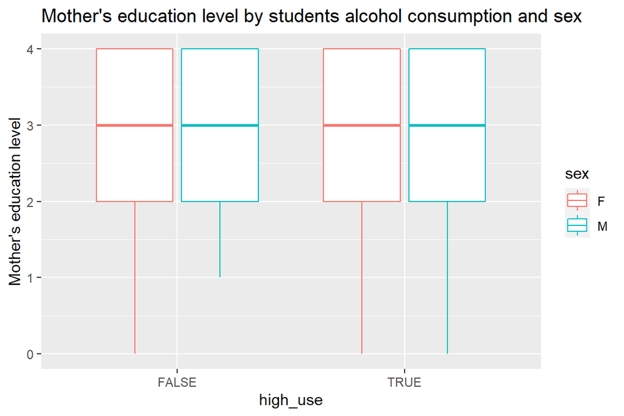

```r
# initialize a plot of high_use and absences
g3 <- ggplot(alc, aes(x = high_use, y = Medu, col = sex))

# define the plot as a boxplot and draw it
g3 + geom_boxplot() + ylab("Mother's education level") + ggtitle("Mother's education level by students alcohol consumption and sex")
```

We can draw a plot box to see the relationship of alcohol consumption, family support and absence, so we can do that. This box plot is not now directly comparable with the previous tables but we can see that there is some relationship between these three variables too.

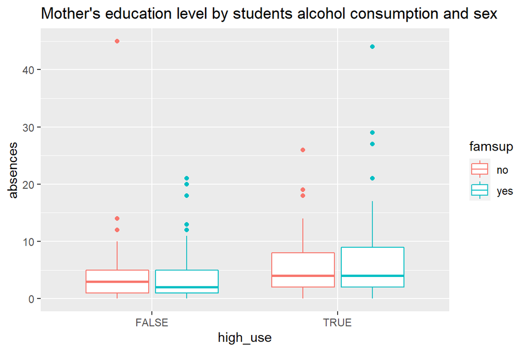

```r
# initialize a plot of high_use and absences
g4 <- ggplot(alc, aes(x = high_use, y = absences, col = famsup))

# define the plot as a boxplot and draw it
g4 + geom_boxplot() + ggtitle("Mother's education level by students alcohol consumption and sex")
```

From the box plots we can already see that our hypothesis h3 (The alcohol consumption is higher among male students whose mothers’ education level is low than female students whose mothers’ education level is low.) is not true. There is no significant difference between the male students whose alcohol consumption is high than with the female students with high alcohol consumption. Actually, we can see that there is no difference between the male and female students whose alcohol consumption is low either. So it seems, as was noted earlier that mothers’ education level does not have any relationship with the students’ alcohol consumption.

There is some evidence showing that the hypotheses h4 and h5, i.e., “h4 The alcohol consumption is higher among male students who do not receive family support than female students who do not receive family support” and “h5 The alcohol consumption is higher among male students with high absences number than female students with high absences number.” Are true but it is not clear how significant this relationship is.

Finally, lets see a summary. It appears that students whose alcohol use is defined as high have higher number of absences. they and are likelier to be male. There is a slight higher number of students whose alcohol consumption is high with high alcohol use but that difference is not significant. And lastly, as we have already discovered, there is basically no relationship between mothers’ education level and the alcohol use. I would normally drop the mothers education level out from further analysis but here I keep it just for the exercise’s sake. I would probably keep the family support variable but do further analysis to select the most parsimonious model that gives an adequate description of the data.

```r
dependent <- "high_use"
explanatory <- c("absences", "sex", "famsup", "Medu")
alc %>%
  summary_factorlist(dependent, explanatory, p = TRUE,
                     add_dependent_label = TRUE)
```

```
##  Dependent: high_use                FALSE      TRUE      p
##             absences Mean (SD)  3.7 (4.5) 6.4 (7.1) <0.001
##                  sex         F 154 (59.5) 41 (36.9) <0.001
##                              M 105 (40.5) 70 (63.1)
##               famsup        no  94 (36.3) 45 (40.5)  0.512
##                            yes 165 (63.7) 66 (59.5)
##                 Medu Mean (SD)  2.8 (1.1) 2.8 (1.1)  0.933
```

## Logistic regression

Let’s explore the distributions of the chosen variables and their relationships with alcohol consumption. Lets first check that the explanatory variables, i.e., sex, absences, family support and mother’s education level are not correlated with one another. The ggpairs() function is a good way of visualising all two-way associations

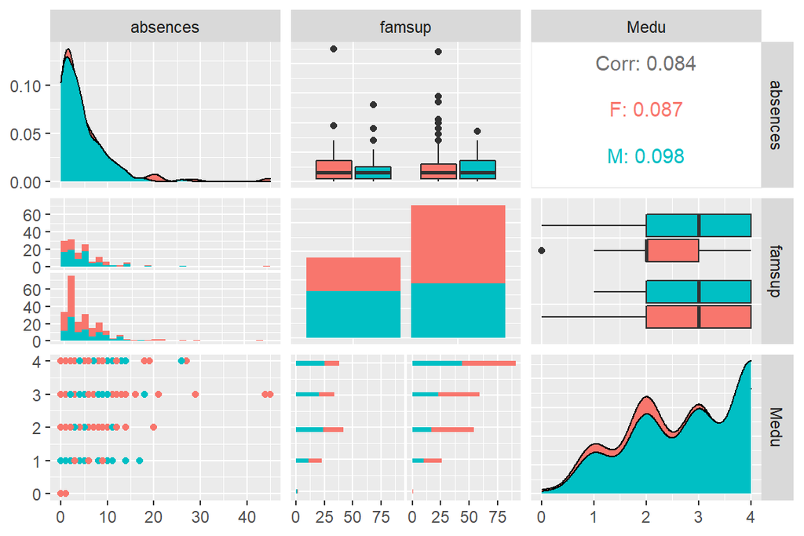

```r
explanatory <- c("absences", "famsup", "Medu")
alc %>%
  remove_labels() %>%
  ggpairs(columns = explanatory, ggplot2::aes(color=sex))
```

We can check the precense of high-order correlations with variance inflation factor which can be calculated for each of the terms.Variance inflation factor tells us how much the variance of a particular regression coefficient is increased due to the presence of multicollinearity in the model. GVIF stands for generalised variance inflation factor. According to the R for [Health Data Science book](https://argoshare.is.ed.ac.uk/healthyr_book/model-assumptions.html), “a common rule of thumb is that if this is greater than 5-10 for any variable, then multicollinearity may exist. The model should be further explored and the terms removed or reduced”. None of the factors are greater than 5-10 so there is no suggestion of any multicollinearity existing.

```r
dependent <- "high_use"
explanatory <- c("absences", "sex", "Medu", "famsup")
alc %>%
  glmmulti(dependent, explanatory) %>%
  car::vif()
```

```
## absences      sex     Medu   famsup
## 1.032858 1.064500 1.052280 1.053462
```

We use `glm()` to fit a logistic regression model with `high_use` as the target variable and `absences`, `sex`, `Medu`, and `famsup` as the predictors.

```r
# find the model with glm()
m <- glm(high_use ~ absences + sex + Medu + famsup, data = alc, family = "binomial")

# print out a summary of the model
summary(m)
```

```
##
## Call:
## glm(formula = high_use ~ absences + sex + Medu + famsup, family = "binomial",
##     data = alc)
##
## Deviance Residuals:
##     Min       1Q   Median       3Q      Max
## -2.2968  -0.8763  -0.6067   1.1127   2.0637
##
## Coefficients:
##              Estimate Std. Error z value Pr(>|z|)
## (Intercept) -1.585134   0.382978  -4.139 3.49e-05 ***
## absences     0.099038   0.023618   4.193 2.75e-05 ***
## sexM         1.057917   0.249816   4.235 2.29e-05 ***
## Medu        -0.102692   0.113867  -0.902    0.367
## famsupyes   -0.006895   0.251175  -0.027    0.978
## ---
## Signif. codes:  0 '***' 0.001 '**' 0.01 '*' 0.05 '.' 0.1 ' ' 1
##
## (Dispersion parameter for binomial family taken to be 1)
##
##     Null deviance: 452.04  on 369  degrees of freedom
## Residual deviance: 414.82  on 365  degrees of freedom
## AIC: 424.82
##
## Number of Fisher Scoring iterations: 4
```

```r
# print out the coefficients of the model
coef(m)
```

```
##  (Intercept)     absences         sexM         Medu    famsupyes
## -1.585134370  0.099037567  1.057917219 -0.102691836 -0.006895319
```

```r
# compute odds ratios (OR)
OR <- coef(m) %>% exp

# compute confidence intervals (CI)
CI <- confint(m) %>% exp
# print out the odds ratios with their confidence intervals
cbind(OR, CI)
```

```
##                    OR      2.5 %    97.5 %
## (Intercept) 0.2049203 0.09470666 0.4265125
## absences    1.1041078 1.05649976 1.1590633
## sexM        2.8803656 1.77683802 4.7406281
## Medu        0.9024050 0.72142713 1.1285336
## famsupyes   0.9931284 0.60860371 1.6321229
```

From the Coefficients we can see that it is safe to say that the null hypothesis that there is no relationship between the students alcohol consumption and the absences, sex, family support and mother’s education level.It is clear that the number of absences and being a man have a relationship with high alcohol consumption. This seems to also confirm that our hypothesis h2, “the alcohol consumption is higher among male than female students” is also true.

The model seems to confirm the hypothesis h5, that the alcohol consumption is higher among male students with high absences number than female students with high absences number. This is because of the coefficients show high significance for male sex and absences. This is further confirmed with the odds ratio and CI levels of these variables. Although, the odd ratio for absences is just a little bit over 1.

The last hypothesis h6, “the alcohol consumption is higher among students who have high number of absences, who are male, have no family support and whose mothers’ education level is low’, is also not true as family support and mother’s education level does not have a significant relationship with the students alcohol consumption.

Here Odds ratio plot which might bring what is said above more clear. Odds ratio value of 1 is the null effect. This means that if the horizontal line crosses this line it does not illustrate statistically significant result.

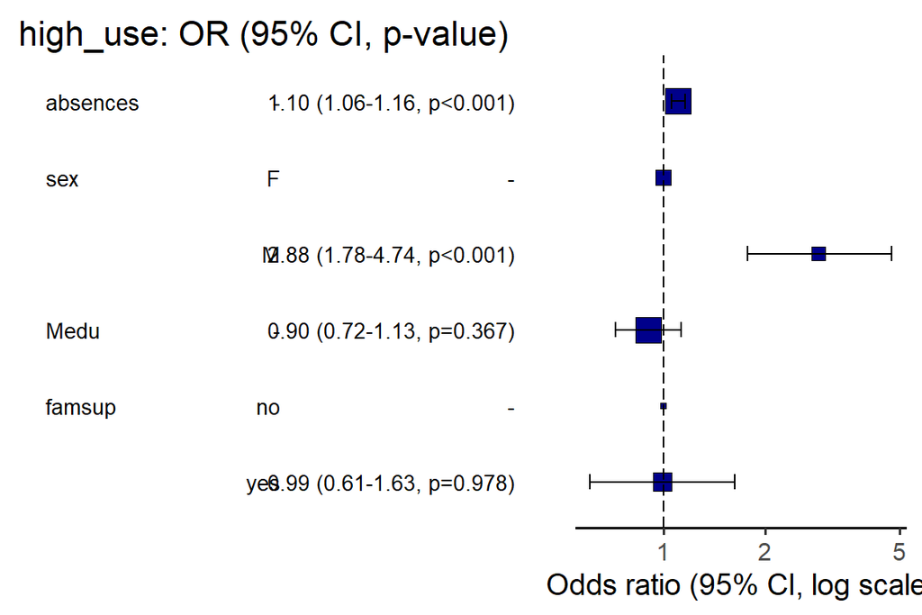

```r
dependent <- "high_use"
explanatory_multi <- c("absences", "sex", "Medu", "famsup")
alc %>%
  or_plot(dependent, explanatory_multi,
          breaks = c(0.5, 1, 2, 5, 10, 25),
          table_text_size = 3.5,
          title_text_size = 16)
```

## The Predictive power of the model

Let’s check how well does our model actually predicts the target variable. We use the `predict()` function to make predictions with a model object. We use the ‘type’ argument of `predict()` to get the predictions as probabilities (instead of log of odds, which is the default).

```r
# predict() the probability of high_use
probabilities <- predict(m, type = "response")

# add the predicted probabilities to 'alc'
alc <- mutate(alc, probability = probabilities)

# use the probabilities to make a prediction of high_use
alc <- mutate(alc, prediction = probability > 0.5)

# look at the first ten observations of the data, along with the predictions
select(alc, failures, absences, sex, high_use, probability, prediction) %>% head(10)
```

```
##    failures absences sex high_use probability prediction
## 1         0        5   F    FALSE   0.1823191      FALSE
## 2         0        3   F    FALSE   0.1981958      FALSE
## 3         2        8   F     TRUE   0.2899708      FALSE
## 4         0        1   F    FALSE   0.1296836      FALSE
## 5         0        2   F    FALSE   0.1542003      FALSE
## 6         0        8   M    FALSE   0.4619290      FALSE
## 7         0        0   M    FALSE   0.3246243      FALSE
## 8         0        4   F    FALSE   0.1670547      FALSE
## 9         0        0   M    FALSE   0.3010742      FALSE
## 10        0        0   M    FALSE   0.3010742      FALSE
```

```r
# tabulate the target variable versus the predictions
table(high_use = alc$high_use, prediction = alc$prediction)
```

```
##         prediction
## high_use FALSE TRUE
##    FALSE   251    8
##    TRUE     84   27
```

The cross tabulation of the predictions versus the actual values (i.e., the confusion matrix) shows that the precision of this model was 27/35, i.e. around 77% and the recall was 27/111, i.e., around 24%

The F1 score of the model is: True Positives/(True Positives + ((False Negatives + False Positives)/2)) which in our case is around 37%. This means that our model does not work very well at all.

## Simple measure of performance

Lets check the penalty function of our model. The less we have penalty the better the model.The loss function of logistic regression shows the loss (the penalty if we predict 0 (in the first calculation) or 1 (in the second calculation)). Here we can see that the cost of predicting 0 is 0.3 which is not too bad but the cost of predicting 1 is 07, which on the other hand is not good at all.

```r
# define a loss function (mean prediction error)
loss_func <- function(class, prob) {
  n_wrong <- abs(class - prob) > 0.5
  mean(n_wrong)
}

# call loss_func to compute the average number of wrong predictions in the (training) data
loss_func(class = alc$high_use, prob = 0)
```

```
## [1] 0.3
```

```r
loss_func(class = alc$high_use, prob = 1)
```

```
## [1] 0.7
```

```r
loss_func(class = alc$high_use, prob = alc$probability)
```

```
## [1] 0.2486486
```

## Bonus: 10-Fold Cross-Validation

```r
cv <- cv.glm(data = alc, cost = loss_func, glmfit = m, K = 10)
cv$delta[1]
```

```
## [1] 0.2567568
```

This model seemed to do slightly better than the model in Exercise3. However, it still did not perform very well. If we want to have model with better performance, there are plenty of ways to do it. Good idea is also to use more time in selecting the variables. You can for example, calculate the R-squared for the last variable added to the model. This will tell how much the R-squared increased for each variable so it will represent the improvement in the goodness-of-fit. (see for example, https://statisticsbyjim.com/regression/identifying-important-independent-variables/)